# Project migration

Carla Domingo, Mah Noor Fatima, Laia Zamora, Carla Zurita and Fatima Zahrae El Yaagoubi

2026-03-12

# Ancient migrations in Southeast Asia

## Description of the data set

Now we answer the following questions:

#### 1. Where and why was the information collected?

The information was collected from ancient human skeletal remains excavated at archaeological sites in Southeast Asia. The samples come from five sites:

- Man Bac (Vietnam)
- Nui Nap (Vietnam)
- Oakaie 1 (Myanmar)
- Ban Chiang (Thailand)
- Vat Komnou (Cambodia)

These remains date from approximately 4100 to 1700 years before present, covering the **Neolithic, Bronze Age, and Iron Age periods**. The researchers extracted ancient DNA (aDNA) from the petrous bone of the skull, which is known to preserve DNA well.

The purpose of collecting this information was to:

- Study ancient human genetic diversity
- Identify mitochondrial DNA haplogroups
- Understand population history and migrations in Southeast Asia
- Evaluate the quality and preservation of ancient DNA samples

#### 2. Which is the meaning of each variable

A subset of variables from the original dataset were selected in order to keep the analysis manageable while still maintaining biological relevance and meeting the requirements of the assignment (at least two discrete variables and three continuous variables).

The selected variables allow us to explore relationships between archaeological context, genetic ancestry, and DNA preservation/quality, which are key aspects in ancient DNA studies.

- **Culture** → Archaeological cultural group associated with the individual (e.g., Neolithic or Bronze Age populations)
- **Location** → The archaeological site where the skeletal remains were found
- **mtDNA haplogroup** → The mitochondrial DNA lineage identified for the individual, reflecting maternal ancestry
- **Equivalent mg bone powder used for library preparation** → Amount of powdered bone used for DNA extraction during sequencing library preparation
- **Shotgun raw sequences** → Total number of DNA sequencing reads obtained from the sample using shotgun sequencing
- **mtDNA coverage** → Average sequencing depth across the mitochondrial genome. Higher coverage indicates more reliable genetic data
- **mtDNA fraction damaged in last base** → Proportion of DNA fragments showing damage at the last nucleotide, a typical feature of ancient DNA degradation

#### 3. Do the variables have units? Which one?

The variables that don’t have units are the culture, location and mtDNA haplogroup as they are categorical variables. The discrete variable that does have units is “Shotgun raw sequences” and represents the number of sequencing reads (count).

On the other hand, our continuous variables do have units. “Equivalent mg bone powder used for library preparation” is in milligrams, “mtDNA coverage” is the average read depth (x coverage) and lastly we have “mtDNA fraction damaged in last base” that is in proportion (0-1).

#### 4. Does the data set have a long format?

Yes, the dataset can be considered close to a long format, because each row represents a single observation (one sequencing library/sample) and each column corresponds to a different variable describing that observation.

## Modification of the data set

First we load the data set **Note:** The file `table_s1.csv` must be located in the same folder as the working directory (i.e., the same folder as the `.Rmd` file). Otherwise, R will not be able to locate and load the dataset.

```r
# Load the readr package
library(readr)
library(dplyr)
```

```r
library(ggplot2)

# Read the CSV
data <- read_csv2(
  "table_s1.csv",
  skip = 1,           # skip the first line which is a description
  locale = locale(decimal_mark = ",") # interpret comma as decimal
)
# Check the first few rows
head(data)
```

```
## # A tibble: 6 × 26
##   `Library ID` `Lab Indiv. ID` `Skeletal codes`    UDG     `Skeletal element`
##   <chr>        <chr>           <chr>               <chr>   <chr>
## 1 S0626.E1.L1  I0626           VN33, 0.7.MB.H1.M10 partial petrous
## 2 S7241.E1.L1  I0626           VN33, 0.7.MB.H1.M10 partial petrous
## 3 S0626.E1.L2  I0626           VN33, 0.7.MB.H1.M10 minus   petrous
## 4 S0626.E1.L3  I0626           VN33, 0.7.MB.H1.M10 minus   petrous
## 5 S0626.E1.L4  I0626           VN33, 0.7.MB.H1.M10 minus   petrous
## 6 S0626.E1.L5  I0626           VN33, 0.7.MB.H1.M10 minus   petrous
## # ℹ 21 more variables: `Date (BCE/CE)` <chr>, Culture <chr>, Location <chr>,
## #   Country <chr>, `Extraction protocol (see key below)` <chr>,
## #   `Library preparation (see key below)` <dbl>,
## #   `Equivalent mg bone powder used for library preparation` <dbl>,
## #   `Shotgun raw sequences` <chr>,
## #   `Shotgun fraction raw sequences mapping to hg19` <chr>,
## #   `mtDNA sequences in alignment` <chr>, …
```

As mentioned previously, we selected a subset of variables from the original dataset to focus on the most relevant biological and technical information for our analysis. This step simplifies the dataset and allows us to work with variables that are meaningful for understanding genetic variation and DNA quality.

The selected variables include information about the archaeological context (Culture, Location), genetic ancestry (mtDNA haplogroup), and sequencing characteristics (amount of bone powder used, number of raw sequences, mtDNA coverage, and DNA damage).

```r
data_subset <- data %>%
  select(
    Culture,
    Location,
    `mtDNA haplogroup`,
    `Equivalent mg bone powder used for library preparation`,
    `Shotgun raw sequences`,
    `mtDNA coverage`,
    `mtDNA fraction damaged in last base`
  )

head(data_subset)
```

```
## # A tibble: 6 × 7
##   Culture           Location `mtDNA haplogroup` Equivalent mg bone powder used…¹
##   <chr>             <chr>    <chr>                                         <dbl>
## 1 Vietnam_Neolithic Man Bac  R                                              26.3
## 2 Vietnam_Neolithic Man Bac  B5                                              8.3
## 3 Vietnam_Neolithic Man Bac  H2a2a                                          13.2
## 4 Vietnam_Neolithic Man Bac  H2a2a1                                         13.2
## 5 Vietnam_Neolithic Man Bac  H40a                                           13.2
## 6 Vietnam_Neolithic Man Bac  H2a2a                                          13.2
## # ℹ abbreviated name: ¹`Equivalent mg bone powder used for library preparation`
## # ℹ 3 more variables: `Shotgun raw sequences` <chr>, `mtDNA coverage` <chr>,
## #   `mtDNA fraction damaged in last base` <chr>
```

After selecting the relevant variables, we removed observations with missing values (NA) to ensure the dataset is clean and suitable for analysis.

```r
data_without_na <- na.omit(data_subset)
```

## Visualization of the data

To explore the dataset, we used different **ggplot2 visualizations** to examine the distribution of variables and summarize relationships between them.

First, we created a **bar plot** to visualize the distribution of the categorical variable *Culture*, with bars filled according to *Location*. This allows us to observe how samples are distributed across different cultures and sites. Additionally, count labels were added on top of each bar to show the exact number of observations per category.

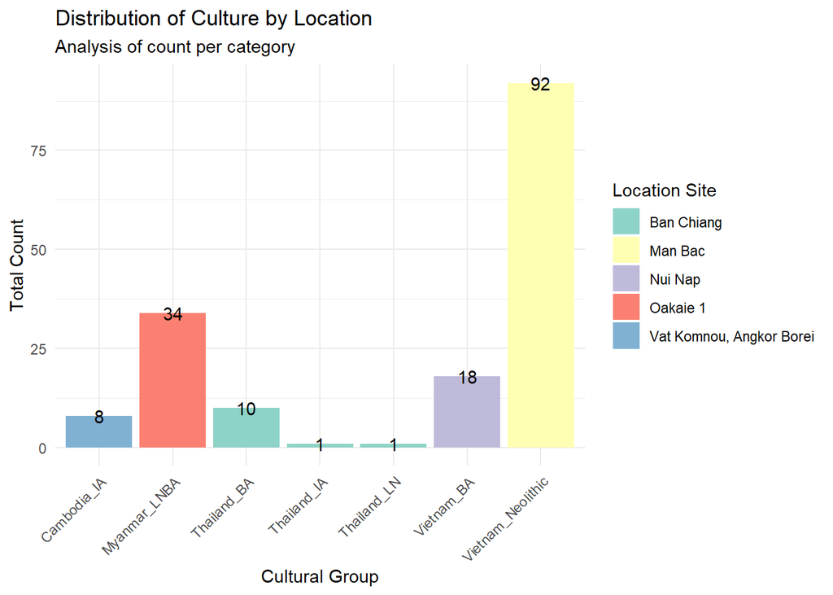

```r
ggplot(data_without_na, aes(Culture, fill=Location)) +
  geom_bar() +
  geom_text(aes(label = ..count..), stat="count", position = position_stack(vjust = 1)) +
  theme_minimal() +
  theme(axis.text.x = element_text(angle=45, hjust = 1)) +
  scale_fill_brewer(palette="Set3") +
  labs(
    title = "Distribution of Culture by Location",
    subtitle = "Analysis of count per category",
    x = "Cultural Group",
    y = "Total Count",
    fill = "Location Site"
  )
```

Following the overview of how samples are distributed across different cultural groups and locations, we explored the genetic composition of these samples. To do this, we created a heatmap showing the distribution of mtDNA haplogroups across the sampled sites. Each tile represents a haplogroup at a specific location, with colors indicating the associated culture. This visualization allows us to quickly compare the presence and relative distribution of genetic lineages among different archaeological sites.

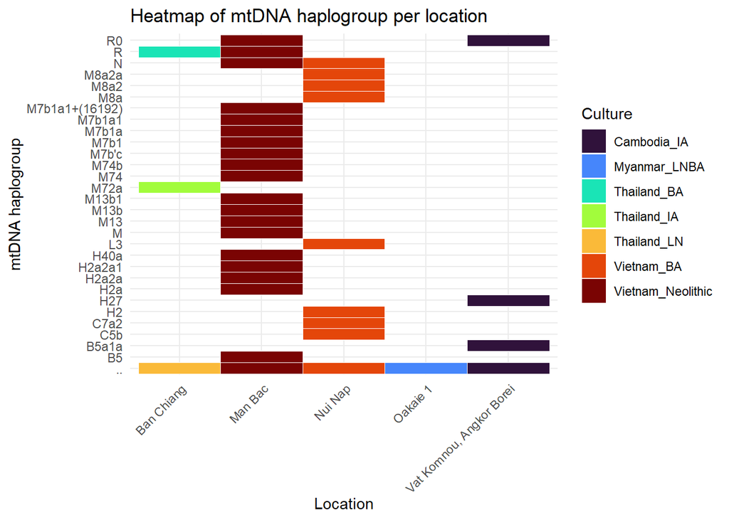

```r
ggplot(data_without_na, aes(Location, `mtDNA haplogroup`, fill = Culture)) +
  geom_tile(color = "white") +
  labs(title = "Heatmap of mtDNA haplogroup per location",
       x = "Location",
       y = "mtDNA haplogroup",
       fill = "Culture") +
  theme_minimal() +
  theme(axis.text.x = element_text(angle = 45, hjust = 1)) +
  scale_fill_viridis_d(option = "turbo")
```

Next, we examined the distribution of a **continuous variable**, *Equivalent mg bone powder used for library preparation*, using a histogram. Before plotting, the variable was converted to numeric format to ensure proper handling in R. The histogram helps us understand how the amount of bone powder used is distributed across samples.

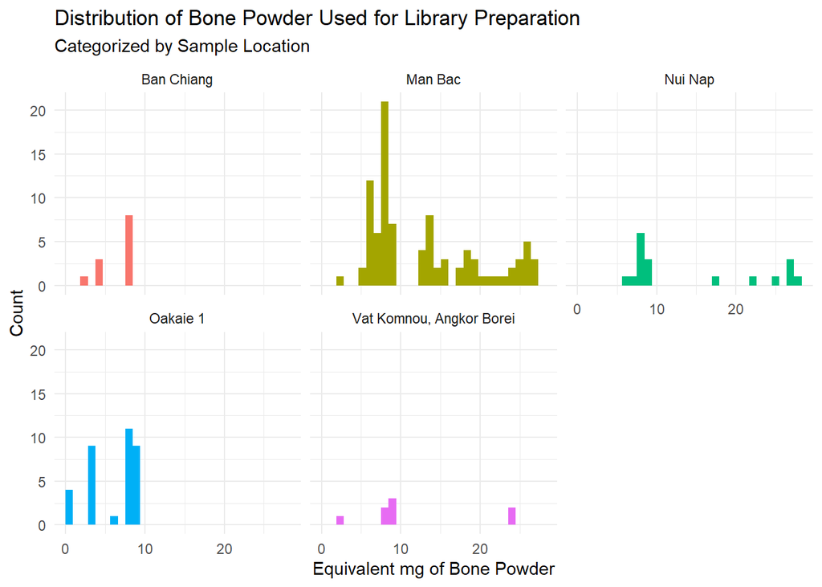

```r
data_without_na$`Equivalent mg bone powder used for library preparation` <- as.numeric(as.character(data_without_na$'Equivalent mg bone powder used for library preparation'))

ggplot(data_without_na, aes(x = `Equivalent mg bone powder used for library preparation`, fill = Location)) +
  geom_histogram(bins = 30) + facet_wrap(~ Location) +  labs(
  title = "Distribution of Bone Powder Used for Library Preparation",
  subtitle = "Categorized by Sample Location",
  x = "Equivalent mg of Bone Powder",
  y = "Count",
) + theme_minimal() + theme(legend.position = "none")
```

Interpretation of the histogram:

The plot shows how much bone powder was used for each sample at different sites. Some sites, like Nui Nap and Man Bac, have a wider range of values, meaning some samples needed more material, likely due to poor DNA preservation. Other sites, like Ban Chiang and Oakaie 1, show more consistent amounts across samples. Overall, this suggests that bone powder use varied between sites, reflecting differences in preservation or lab processing.

Finally, we used a **boxplot** to summarize the relationship between *Culture* (categorical variable) and the amount of bone powder used (continuous variable), with colors representing different locations. This visualization provides insight into the variability, median values, and potential outliers across groups, allowing comparison between cultures and locations.

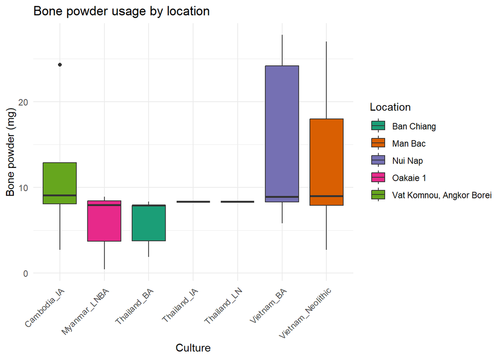

```r
ggplot(data_without_na, aes(x = Culture, y = `Equivalent mg bone powder used for library preparation`, fill = Location)) +
geom_boxplot() + labs(title = "Bone powder usage by location",y = "Bone powder (mg)") + theme_minimal() + theme(axis.text.x = element_text(angle=45, hjust = 1)) +
scale_fill_brewer(palette = "Dark2")
```

Interpretation of the boxplot:

The figure shows that bone powder use varies noticeably between sites. Locations such as Nui Nap and Man Bac have higher and more spread-out values, meaning that some individuals were associated with much larger amounts of bone powder than others. In contrast, sites like Ban Chiang and Oakaie 1 show lower and more consistent values, suggesting less variation in how bone powder was used. Vat Komnou falls somewhere in between, with moderate values but one notably high example.

Overall, this pattern suggests that some sites required more bone material per individual or had greater variability in sampling, while others followed a more consistent approach.

Hypothesis of the boxplot:

The variation in bone powder is likely influenced by differences in DNA preservation and sampling strategy across sites and time periods. Tropical environments are known to cause poor DNA preservation, meaning that some samples require more bone powder and multiple sequencing libraries to obtain usable genetic data.

Sites such as Man Bac (Neolithic) and Nui Nap (Bronze Age) may show higher and more variable bone powder usage because preservation conditions differed between individuals, leading researchers to process more material in some cases to recover sufficient DNA. In contrast, the more consistent values at Ban Chiang and Oakaie 1 may reflect more uniform preservation or more standardized sampling strategies.